# ggkegg

Noriaki Sato

22 6月 2023

# 1 ggkegg

This package aims to import, parse, and analyze KEGG data such as KEGG PATHWAY and KEGG MODULE. The package supports visualizing KEGG information using ggplot2 and ggraph through using the grammar of graphics. The package enables the direct visualization of the results from various omics analysis packages. As we will not download the raw KEGG information in this vignette, please refer to [the documentation](https://noriakis.github.io/software/ggkegg) for the detailed usage.

## 1.1 Pathway

Here we prepare an example `tbl_graph` representing pathway information. Typically one can obtain a real KEGG PATHWAY `tbl_graph` by `pathway` function. If you want to cache the file, please specify `use_cache=TRUE`, and if you already have the XML files of the pathway, please specify the directroy with `directory` argument.

```r
library(ggkegg)
graph <- return_pathway_example()
graph
```

```
## # A tbl_graph: 2 nodes and 2 edges
## #
## # A directed acyclic multigraph with 1 component
## #
## # A tibble: 2 × 14
##   name  type  reaction graphics_name     x     y width height bgcolor pathway_id
##   <chr> <chr> <lgl>    <chr>         <dbl> <dbl> <dbl>  <dbl> <chr>   <chr>
## 1 hsa:… gene  NA       TRIM21          560  -400    20      9 #BFFFBF test
## 2 hsa:… gene  NA       DDX41           500  -400    20      9 #BFFFBF test
## # ℹ 4 more variables: xmin <dbl>, ymin <dbl>, xmax <dbl>, ymax <dbl>
## #
## # A tibble: 2 × 4
##    from    to subtype_name   pathway_id
##   <int> <int> <chr>          <chr>
## 1     1     2 degradation    test
## 2     1     2 ubiquitination test
```

```r
# graph <- pathway("hsa04110")
# graph <- pathway("hsa04110", directory="path/to/xml")
# graph <- pathway("hsa04110", use_cache=TRUE)
```

### 1.1.1 Plot using `ggraph`

The parsed `tbl_graph` can be used to plot the information by `ggraph`.

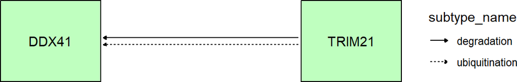

```r
ggraph(graph, layout="manual", x=x, y=y)+
  geom_node_rect(aes(fill=I(bgcolor)), color="black")+
  geom_node_text(aes(label=graphics_name))+
  geom_edge_parallel(aes(linetype=subtype_name),
                   arrow=arrow(length=unit(1,"mm"),
                               type="closed"),
                   end_cap=circle(1.5,"cm"),
                   start_cap=circle(1.5,"cm"))+
  theme_void()
```

## 1.2 Converting identifiers

The user can convert identifiers using `convert_id` function to be used in `mutate`. One can pipe the functions to convert `name` column consisting of `hsa` KEGG gene IDs in node table of `tbl_graph` and plot them.

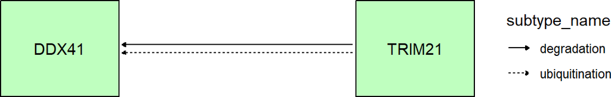

```r
graph |>
  activate(nodes) |>
  mutate(hsa=convert_id("hsa")) |>
  ggraph(layout="manual", x=x, y=y)+
  geom_node_rect(aes(fill=I(bgcolor)), color="black")+
  geom_node_text(aes(label=hsa))+ ## specify converted column in node table
  geom_edge_parallel(aes(linetype=subtype_name),
                   arrow=arrow(length=unit(1,"mm"),
                               type="closed"),
                   end_cap=circle(1.5,"cm"),
                   start_cap=circle(1.5,"cm"))+
  theme_void()
```

### 1.2.1 Overlaying raw KEGG image

We can use `overlay_raw_map` to overlay the raw KEGG images on the created ggraph. The node and text can be directly customized by using various geoms and effects such as `ggfx`. The code below creates nodes using default parsed background color and just overlay the image.

```r
# graph <- pathway("hsa04110")
# ggraph(graph, layout="manual", x=x, y=y)+
#   geom_node_rect(aes(fill=I(bgcolor)))+
#   overlay_raw_map()
```

### 1.2.2 Use with the other omics packages

The package supports direct importing and visualization, and investigation of the results of the other packages such as enrichment analysis results from `clusterProfiler` and differential expression analysis results from `DESeq2`. As this involves downloading the pathway information, please refer to [use cases](https://noriakis.github.io/software/ggkegg/usecases.html) in the documentation.

## 1.3 Module

### 1.3.1 Parsing module

KEGG MODULE can be parsed and used in the analysis. The formula to obtain module is the same as pathway. Here, we use test pathway which contains two KEGG ORTHOLOGY, two compounds and one reaction. This will create `kegg_module` class object storing definition and reactions.

```r
mod <- create_test_module()
# module("M00002", use_cache=TRUE)
mod
```

```
## test
## test module
```

### 1.3.2 Visualizing module

The module can be visualized by text-based or network-based, depicting how they interact.

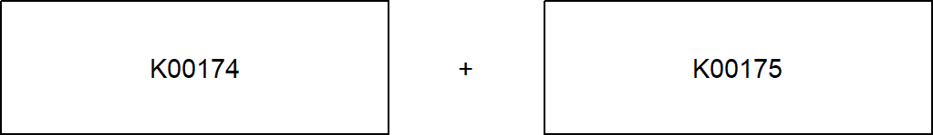

```r
## Text-based
mod |>
  module_text() |> ## return data.frame
  plot_module_text()
```

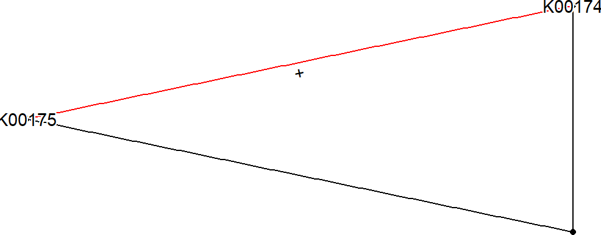

```r
## Network-based
mod |>
  obtain_sequential_module_definition() |>## return tbl_graph
ggraph()+
  geom_node_point()+
  geom_edge_link(aes(label=type, filter=!startsWith(type,"in_")),
                 label_dodge = unit(2,"mm"), color="red", angle_calc = "along")+
    geom_edge_link(aes(filter= startsWith(type,"in_")))+ ## Additional edges specifying grouped relationship
  geom_node_shadowtext(aes(label=name, filter=startsWith(name,"K")),
                       bg.colour="white", color="black")+
  theme_graph()
```

```r
## plot_module_blocks() can be used for module containing definitions with multiple blocks
```